# Trivial Notes on the Data Acquisition Process (OUTDATED - NOT RELEVANT)

```python
cd /Users/Leonard/Desktop/Bachelors
```

```
/Users/Leonard/Desktop/Bachelors
```

```python
from matplotlib import pyplot as plt
import time
%config InlineBackend.figure_format = 'retina'
%matplotlib inline

plt.style.use("seaborn")
plt.rcParams["figure.figsize"] = (15,6.25)
plt.rcParams["figure.dpi"] = 85

import numpy as np
import pandas as pd
```

# 0 Data Gathering

```python
from yahoofinancials import YahooFinancials
from DailyTrends.collect import collect_data
```

### 0.1 Market data

```python
def pull_stock_data(ticker:str,
                    start="2004-01-01",
                    end="2019-01-01",
                    freq="daily") -> pd.DataFrame:
    yahoo_financials = YahooFinancials(ticker)
    data = yahoo_financials.get_historical_price_data(start, end, freq)
    df = pd.DataFrame(data[ticker]["prices"])
    df.index = df.formatted_date.astype("datetime64")
    df.index.name = "date"
    return df.asfreq("D").fillna(method="ffill")
```

#### Example

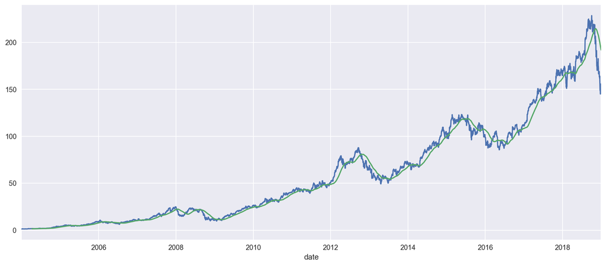

```python
apple = pull_stock_data("AAPL")
ax=apple["adjclose"].plot(); apple["adjclose"].rolling(100).mean().plot(ax=ax)
```

Simple Returns

$$ R_t = \frac{p_t}{p_{t-1}} - 1 $$

Log-Returns

$$ \ln{(R_t)} = \ln{(1+R_{t})} = \ln{(\frac{p_t}{p_{t-1}})} $$$$ \leftrightarrow \ln{(1+R(t))} $$

Monthly volatility

$$ \frac{1}{21} \sum_{t=1}^{21} \ln{(1+R(t))}^{2} $$

```python
apple["R"] = apple["adjclose"].pct_change()
apple["log(R)"] = np.log(1 + apple["R"])
```

[output not shown]

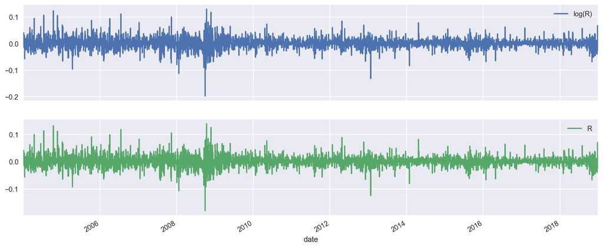

```python
apple[["log(R)", "R"]].plot(subplots=True)
```

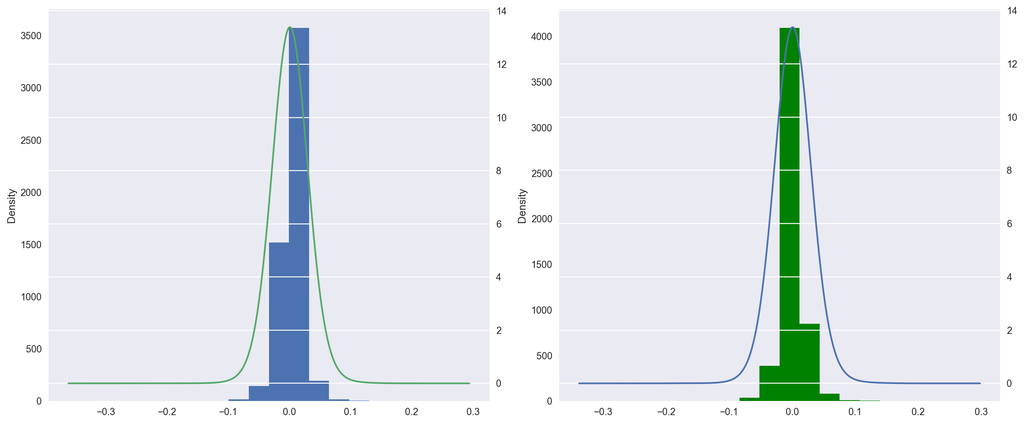

```python
fig, axes = plt.subplots(nrows=1, ncols=2)
apple["log(R)"].hist(ax=axes[0]);apple["log(R)"].plot.kde(1.5, ax=axes[0], secondary_y=True)
apple["R"].hist(ax=axes[1], color="green");apple["R"].plot.kde(1.5, ax=axes[1], secondary_y=True)
fig.tight_layout()
```

### Testing Spearmans $\rho$ for $R(t)$ against $R(t-l)$ for $l \in 1\to1000$

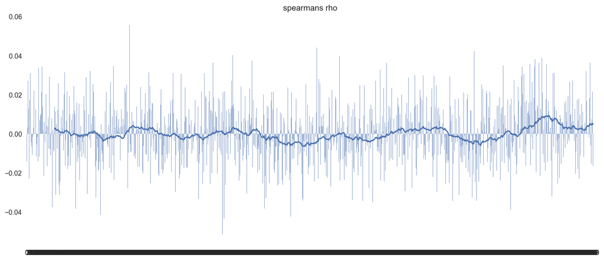

```python
ax=pd.Series([apple.R.corr(apple["R"].shift(i),
                       method="spearman") for i in range(1, 1001)]).plot(title="spearmans rho", kind="bar")
pd.Series([apple.R.corr(apple["R"].shift(i),
                       method="spearman") for i in range(1, 1001)]).rolling(50).mean().plot(ax=ax)
```

For this analysis, I will obtain the historic stock prices records for all the S&P500 companies.

```python
import bs4 as bs, requests, time
from tqdm import tqdm
```

```python
#Scrape the S&P500 company tickers and their names
def get_tickers():
    resp = requests.get('http://en.wikipedia.org/wiki/List_of_S%26P_500_companies')
    soup = bs.BeautifulSoup(resp.text, 'lxml')
    table = soup.find('table', {'class': 'wikitable sortable'})
    data = []
    for row in table.findAll('tr')[1:]:
        ticker = row.findAll('td')[0].text
        name = row.findAll('td')[1].text
        data.append({"ticker" : ticker.rstrip("\n"), "name" : name})
    return data
```

```python
companies = get_tickers()
print("There are {} total companies".format(len(companies)))
```

```
There are 505 total companies
```

```python
[_["name"] for _ in companies][0:20]
```

```
['3M Company',
 'Abbott Laboratories',
 'AbbVie Inc.',
 'ABIOMED Inc',
 'Accenture plc',
 'Activision Blizzard',
 'Adobe Systems Inc',
 'Advanced Micro Devices Inc',
 'Advance Auto Parts',
 'AES Corp',
 'Affiliated Managers Group Inc',
 'AFLAC Inc',
 'Agilent Technologies Inc',
 'Air Products & Chemicals Inc',
 'Akamai Technologies Inc',
 'Alaska Air Group Inc',
 'Albemarle Corp',
 'Alexandria Real Estate Equities',
 'Alexion Pharmaceuticals',
 'Align Technology']
```

Now I will remove things like "Incorporated, Inc, Inc., Corporation, Corp., Group" since those suffixes are commonly irrelevant when quering for information on the web.

```python
unwanted_suffixes = ["," , "Inc.", "Inc", "Incorporated",
                     "Corporation", "Corp", "Corp.",
                     "Co.", "Co", "& Co", "Group", "Gp.", "& Co.",
                     "Company", "plc", "Technology", "Technologies",
                    "Laboratories", "Pharmaceuticals", "Systems", "Holdings", "Ltd.", "Limited",
                    ".com", "Communications", "Industries", "International", "Trust", "Services", "Ltd"
                    "Class A", "Class C", "Class B"]
for company in companies:
    name = company["name"]
    for stopword in unwanted_suffixes:
        if name.endswith(stopword):
            company["name"] = name[:-len(stopword)].rstrip()
            break
```

```python
#This should look better
[_["name"] for _ in companies][0:20]
```

[output not shown]

```python
#Collect and append stock price data for all companies
for company in companies:
    if "price_data" not in company:
        ticker = company["ticker"]
        try:data = pull_stock_data(ticker)
        except:continue
        company["price_data"] = data
```

```python
companies = [_ for _ in companies if "price_data" in _]
print("I obtained a total of {} companies for further analysis".format(len(companies)))
```

[output not shown]

```python
#Save data
import pickle
with open("companies_w_prices_newest", "wb") as f:
    pickle.dump(companies, f)
```

## 0.1 Query data

```python
Q = ["stock", "share"]
ticker, name = "AAPL", "Apple"

[ticker, name] + [_+" "+suffix for _ in [ticker, name] for suffix in Q]
```

```
['AAPL', 'Apple', 'AAPL stock', 'AAPL share', 'Apple stock', 'Apple share']
```

```python
def pull_query_data(Q:list, company) -> pd.DataFrame:
    ticker, name = company["ticker"], company["name"]
    Q = [ticker, name] + [_+" "+suffix for _ in [ticker, name] for suffix in Q]
    dfs = []
    for q in Q:
        data = collect_data(q)
        dfs.append(data)
    df = pd.merge(dfs[0], dfs[1], left_index=True, right_index=True)
    for x in dfs[2:]:
        df = pd.merge(df, x, left_index=True, right_index=True)
    return df
```

```python
#Define a Query list
Q = ["stock", "share"]
#Append query data
for company in companies:
    data = pull_query_data(Q, company)
    data.columns = [i.replace(": (Worldwide)", "") for i in data.columns]
    company["query_data"] = data
```

### Example

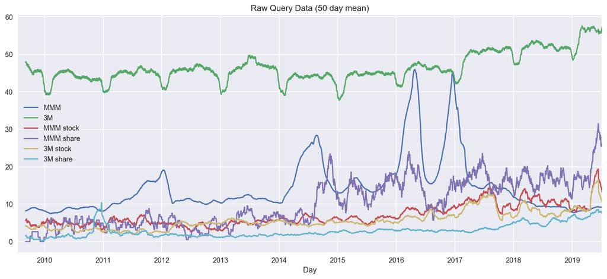

```python
companies[0]["query_data"].rolling(50).mean().plot(title="Raw Query Data (50 day mean)")
```

### Query data imputation rule (OUTDATED)

Since I want to compute `pct_change`for the queries, I need to impute zero-values.

For a given value $x_i \in q \ \ \forall \ \ q \in Q$ it is known that

$$ x_i = \begin{cases} 0, & \text{if $x_i < T$}\\ x_i, & \text{otherwise} \end{cases} $$

where $T$ is a threshold value which is not public. Altough it is possible to reversly find $T$, I think that simply imputing $T$ will yield reasonable results.

Possibilities on how to impute :

1. Use last value
   - Reasonable since this is a time series
2. Gaussian Noise around $0$
3. Use a value which is just a little bit smaller than the smallest value within the series.

```python
company = companies[0]
#merge data
data = pd.merge(company["query_data"], company["price_data"], right_index=True, left_index=True)
data = data[['MMM', '3M', 'MMM stock', 'MMM share', '3M stock', '3M share','adjclose']]
data["R"] = data["adjclose"].pct_change()
data["log(R)"] = np.log(1 + data["R"])
data.pop("adjclose")
data.pop("R")
```

```python
## toy imputation and pct change transformation
for c in data:
    if c not in ["adjclose", "R", "log(R)"]:
        data[c] = data[c].replace(to_replace=0, value=.999)
        data[c] = data[c].pct_change()
```

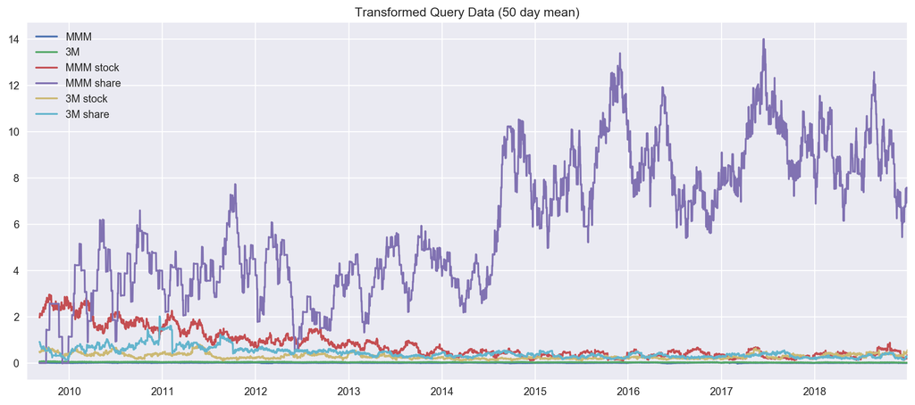

```python
data[['MMM', '3M', 'MMM stock',
      'MMM share', '3M stock',
      '3M share']].rolling(50).mean().plot(title="Transformed Query Data (50 day mean)")
```

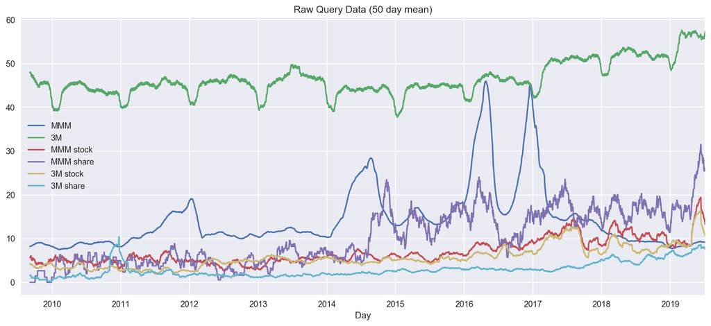

```python
companies[0]["query_data"].rolling(50).mean().plot(title="Raw Query Data (50 day mean)")
```